# Pinnacle Upholsters

Sales Department

# Introduction

This report describes the sales made by Pinnacle Upholsters for the month of `August` in `2015`. Goods sold are divided into `3` distinct segments,i.e `Consumer`, `Corporate` and `Home Office`. Each of these segments are further divided into `4` ship modes, namely: `First Class`, `Same Day`, `Second Class` and `Standard Class`

## Consumer

### First Class

- Total sales made: Ksh. 786.608

### Same Day

- Total sales made: Ksh. 89.32

### Second Class

- Total sales made: Ksh. 246.8

### Standard Class

- Total sales made: Ksh. 892.084

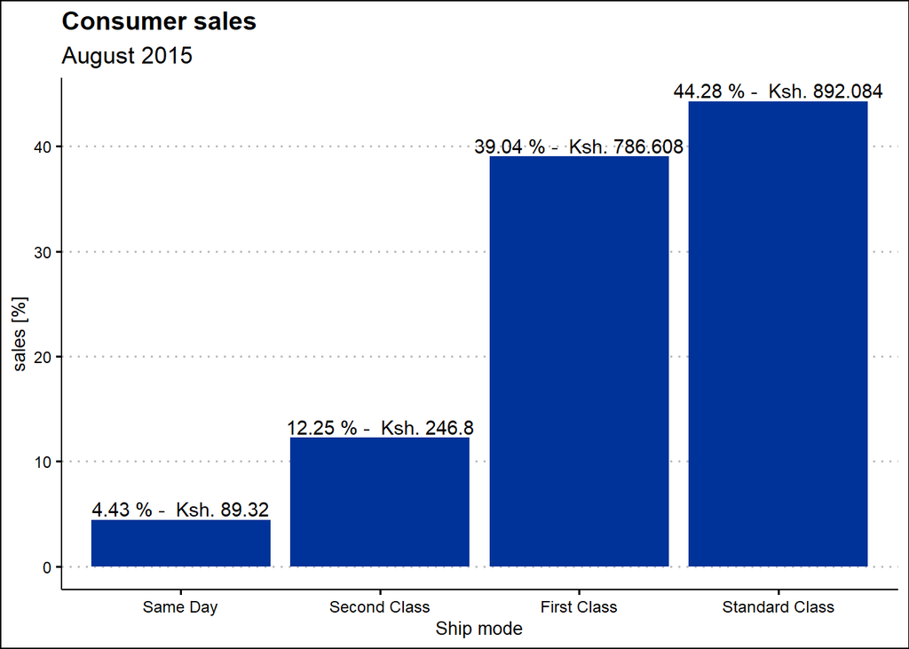

## Corporate

### First Class

- Total sales made: Ksh. 31.008

### Same Day

- Total sales made: Ksh. 0

### Second Class

- Total sales made: Ksh. 0

### Standard Class

- Total sales made: Ksh. 768.5585

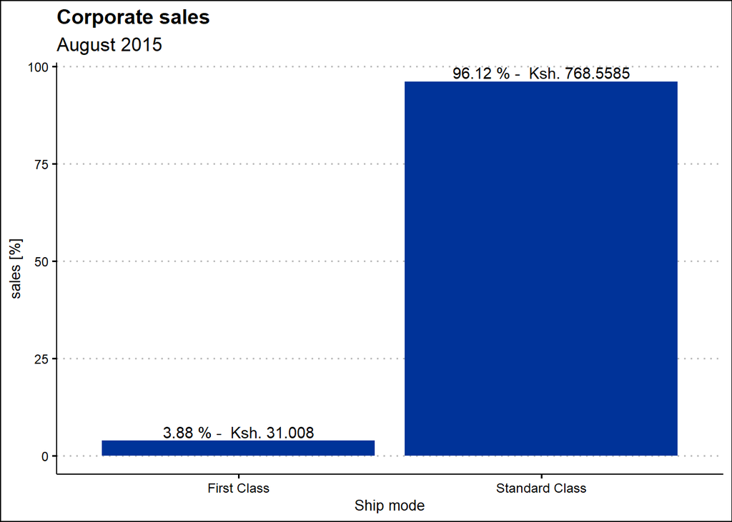

## Home Office

### First Class

- Total sales made: Ksh. 0

### Same Day

- Total sales made: Ksh. 0

### Second Class

- Total sales made: Ksh. 0

### Standard Class

- Total sales made: Ksh. 235.632

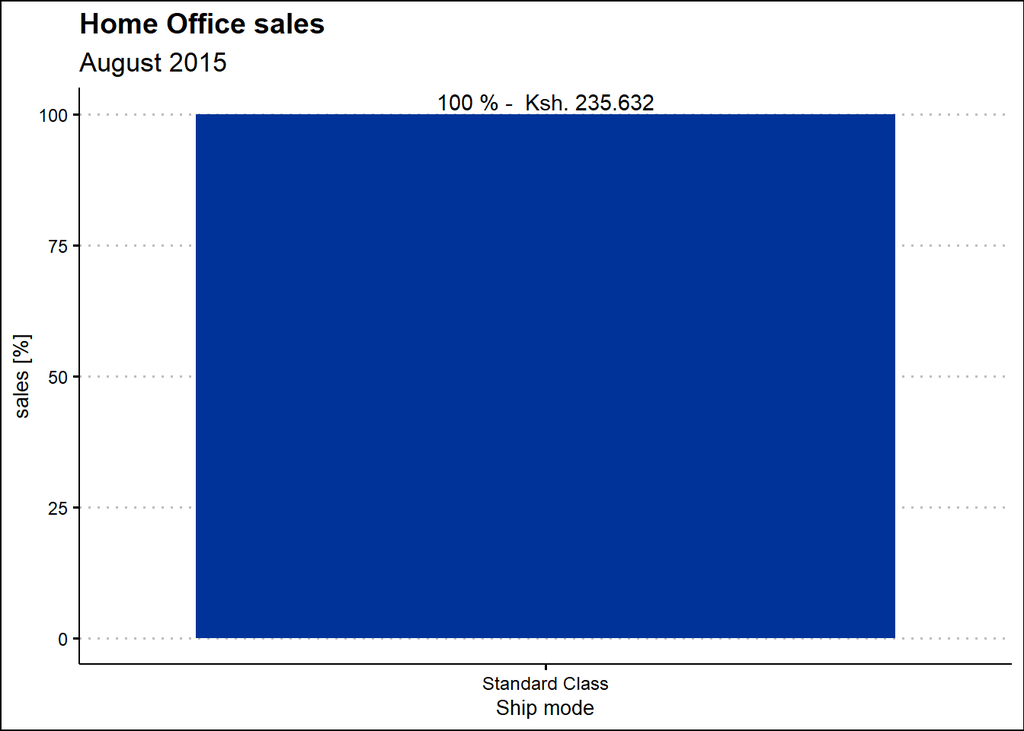

# Insights

- Total monthly sales `Ksh. 3050.0105`
- Percentage change in `total monthly sales`,with respect to last month is `-61.22 %`

## Segments

- `Consumer` was the top-performing segment raking in `Ksh 2014.812` which translates to `66.06 %` of the total monthly revenue.
- `Home Office` was the biggest underperformer, bringing in `7.73 %` of the total revenue.

## Shipping modes

- `Standard Class` goods fetched `Ksh. 892.084` which is `44.28 %` of all the sales made from the `Consumer` segment.
- `Standard Class` goods fetched `Ksh. 768.5585` which is `96.12 %` of all the sales made from the `Corporate` segment.
- `Standard Class` goods fetched `Ksh. 235.632` which is `100 %` of all the sales made from the `Home Office` segment.
- `Corporate Second Class, Corporate Same Day, Home Office First Class, Home Office Second Class, Home Office Same Day` combinations made `no revenue` for the month.

## Customer orders

- Total number of orders: `16`
  - `Consumer`: `50 %`
  - `Corporate`: `25 %`
  - `Home Office`: `25 %`
- The average value of orders made in Ksh.:

  | segment | average_order_value |
  | --- | --- |
  | Consumer | 251.8515 |
  | Corporate | 199.8916 |
  | Home Office | 58.9080 |